# Summaries

2019-03-18

```r
library(tidyverse)
library(nycflights13)
```

dplyr summarise() function can be used to calculate counts and proportions of logical values: sum(x > 10), mean(y == 0).

When used with numeric functions, TRUE is converted to 1 and FALSE to 0.

> This makes sum() and mean() very useful: sum(x) gives the number of TRUEs in x, and mean(x) gives the proportion.

### Exercises

1. Using nycflights13 “flights” dataset, brainstorm at least 5 different ways to assess the typical delay characteristics of a group of flights.

```r
flights
```

```
## # A tibble: 336,776 x 19
##     year month   day dep_time sched_dep_time dep_delay arr_time
##    <int> <int> <int>    <int>          <int>     <dbl>    <int>
##  1  2013     1     1      517            515         2      830
##  2  2013     1     1      533            529         4      850
##  3  2013     1     1      542            540         2      923
##  4  2013     1     1      544            545        -1     1004
##  5  2013     1     1      554            600        -6      812
##  6  2013     1     1      554            558        -4      740
##  7  2013     1     1      555            600        -5      913
##  8  2013     1     1      557            600        -3      709
##  9  2013     1     1      557            600        -3      838
## 10  2013     1     1      558            600        -2      753
## # … with 336,766 more rows, and 12 more variables: sched_arr_time <int>,
## #   arr_delay <dbl>, carrier <chr>, flight <int>, tailnum <chr>,
## #   origin <chr>, dest <chr>, air_time <dbl>, distance <dbl>, hour <dbl>,
## #   minute <dbl>, time_hour <dttm>
```

```r
str(flights)
```

```
## Classes 'tbl_df', 'tbl' and 'data.frame':    336776 obs. of  19 variables:
##  $ year          : int  2013 2013 2013 2013 2013 2013 2013 2013 2013 2013 ...
##  $ month         : int  1 1 1 1 1 1 1 1 1 1 ...
##  $ day           : int  1 1 1 1 1 1 1 1 1 1 ...
##  $ dep_time      : int  517 533 542 544 554 554 555 557 557 558 ...
##  $ sched_dep_time: int  515 529 540 545 600 558 600 600 600 600 ...
##  $ dep_delay     : num  2 4 2 -1 -6 -4 -5 -3 -3 -2 ...
##  $ arr_time      : int  830 850 923 1004 812 740 913 709 838 753 ...
##  $ sched_arr_time: int  819 830 850 1022 837 728 854 723 846 745 ...
##  $ arr_delay     : num  11 20 33 -18 -25 12 19 -14 -8 8 ...
##  $ carrier       : chr  "UA" "UA" "AA" "B6" ...
##  $ flight        : int  1545 1714 1141 725 461 1696 507 5708 79 301 ...
##  $ tailnum       : chr  "N14228" "N24211" "N619AA" "N804JB" ...
##  $ origin        : chr  "EWR" "LGA" "JFK" "JFK" ...
##  $ dest          : chr  "IAH" "IAH" "MIA" "BQN" ...
##  $ air_time      : num  227 227 160 183 116 150 158 53 140 138 ...
##  $ distance      : num  1400 1416 1089 1576 762 ...
##  $ hour          : num  5 5 5 5 6 5 6 6 6 6 ...
##  $ minute        : num  15 29 40 45 0 58 0 0 0 0 ...
##  $ time_hour     : POSIXct, format: "2013-01-01 05:00:00" "2013-01-01 05:00:00" ...
```

```r
head(flights)
```

```
## # A tibble: 6 x 19
##    year month   day dep_time sched_dep_time dep_delay arr_time
##   <int> <int> <int>    <int>          <int>     <dbl>    <int>
## 1  2013     1     1      517            515         2      830
## 2  2013     1     1      533            529         4      850
## 3  2013     1     1      542            540         2      923
## 4  2013     1     1      544            545        -1     1004
## 5  2013     1     1      554            600        -6      812
## 6  2013     1     1      554            558        -4      740
## # … with 12 more variables: sched_arr_time <int>, arr_delay <dbl>,
## #   carrier <chr>, flight <int>, tailnum <chr>, origin <chr>, dest <chr>,
## #   air_time <dbl>, distance <dbl>, hour <dbl>, minute <dbl>,
## #   time_hour <dttm>
```

```r
flight_delay_summary <- group_by(flights, flight) %>% summarise(num_flights = n(),

                                          percentage_on_time = sum(arr_time == sched_arr_time)/num_flights,
                                          percentage_early = sum(arr_time < sched_arr_time)/num_flights,
                                          percentage_10_mins_late = sum(arr_time - sched_arr_time == 10)/num_flights,
                                          percentage_15_mins_early = sum(sched_arr_time - arr_time == 15)/num_flights,
                                          percentage_15_mins_late = sum(arr_time - sched_arr_time == 15)/num_flights,
                                          percentage_30_mins_early = sum(sched_arr_time - arr_time == 30)/num_flights,
                                          percentage_30_mins_late = sum(arr_time - sched_arr_time == 30)/num_flights,
                                          percentage_2_hours_late = sum(arr_time - sched_arr_time == 120)/num_flights)
flight_delay_summary
```

```
## # A tibble: 3,844 x 10
##    flight num_flights percentage_on_t… percentage_early percentage_10_m…
##     <int>       <int>            <dbl>            <dbl>            <dbl>
##  1      1         701         NA                 NA             NA
##  2      2          51          0.0392             0.725          0
##  3      3         631         NA                 NA             NA
##  4      4         393         NA                 NA             NA
##  5      5         324          0.00617            0.716          0.00617
##  6      6         210         NA                 NA             NA
##  7      7         237         NA                 NA             NA
##  8      8         236         NA                 NA             NA
##  9      9         153         NA                 NA             NA
## 10     10          61          0.0164             0.721          0.0328
## # … with 3,834 more rows, and 5 more variables:
## #   percentage_15_mins_early <dbl>, percentage_15_mins_late <dbl>,
## #   percentage_30_mins_early <dbl>, percentage_30_mins_late <dbl>,
## #   percentage_2_hours_late <dbl>
```

Consider the following scenarios:

- A flight is 15 minutes early 50% of the time, and 15 minutes late 50% of the time.

```r
flight_delay_summary %>%
  filter(percentage_15_mins_early == 0.5 & percentage_15_mins_late == 0.5)
```

```
## # A tibble: 0 x 10
## # … with 10 variables: flight <int>, num_flights <int>,
## #   percentage_on_time <dbl>, percentage_early <dbl>,
## #   percentage_10_mins_late <dbl>, percentage_15_mins_early <dbl>,
## #   percentage_15_mins_late <dbl>, percentage_30_mins_early <dbl>,
## #   percentage_30_mins_late <dbl>, percentage_2_hours_late <dbl>
```

- A flight is always 10 minutes late.

```r
flight_delay_summary  %>%
  filter(percentage_10_mins_late == 1)
```

```
## # A tibble: 3 x 10
##   flight num_flights percentage_on_t… percentage_early percentage_10_m…
##    <int>       <int>            <dbl>            <dbl>            <dbl>
## 1   2254           1                0                0                1
## 2   3880           1                0                0                1
## 3   5854           1                0                0                1
## # … with 5 more variables: percentage_15_mins_early <dbl>,
## #   percentage_15_mins_late <dbl>, percentage_30_mins_early <dbl>,
## #   percentage_30_mins_late <dbl>, percentage_2_hours_late <dbl>
```

- A flight is 30 minutes early 50% of the time, and 30 minutes late 50% of the time.
- 99% of the time a flight is on time. 1% of the time it’s 2 hours late.

```r
flight_delay_summary %>%
  filter(percentage_30_mins_early== 0.5 & percentage_30_mins_late == 0.5)
```

```
## # A tibble: 0 x 10
## # … with 10 variables: flight <int>, num_flights <int>,
## #   percentage_on_time <dbl>, percentage_early <dbl>,
## #   percentage_10_mins_late <dbl>, percentage_15_mins_early <dbl>,
## #   percentage_15_mins_late <dbl>, percentage_30_mins_early <dbl>,
## #   percentage_30_mins_late <dbl>, percentage_2_hours_late <dbl>
```

```r
flight_delay_summary %>%
  filter(percentage_on_time == 0.99 & percentage_2_hours_late == 0.01)
```

```
## # A tibble: 0 x 10
## # … with 10 variables: flight <int>, num_flights <int>,
## #   percentage_on_time <dbl>, percentage_early <dbl>,
## #   percentage_10_mins_late <dbl>, percentage_15_mins_early <dbl>,
## #   percentage_15_mins_late <dbl>, percentage_30_mins_early <dbl>,
## #   percentage_30_mins_late <dbl>, percentage_2_hours_late <dbl>
```

- Which is more important: arrival delay or departure delay?

Both are imortant.

2. Come up with another approach that will give you the same output as not_cancelled %>% count(dest) and not_cancelled %>% count(tailnum, wt = distance) (without using count()).

```r
not_cancelled <-
  flights %>%
  filter(!is.na(dep_delay), !is.na(arr_delay))
not_cancelled %>%
  count(dest)
```

```
## # A tibble: 104 x 2
##    dest      n
##    <chr> <int>
##  1 ABQ     254
##  2 ACK     264
##  3 ALB     418
##  4 ANC       8
##  5 ATL   16837
##  6 AUS    2411
##  7 AVL     261
##  8 BDL     412
##  9 BGR     358
## 10 BHM     269
## # … with 94 more rows
```

3. Our definition of cancelled flights (is.na(dep_delay) | is.na(arr_delay) ) is slightly suboptimal. Why? Which is the most important column?

There are no flights that arrived but did not depart.

```r
flights %>%
    group_by(departed = !is.na(dep_delay), arrived = !is.na(arr_delay)) %>%
    summarise(n=n())
```

```
## # A tibble: 3 x 3
## # Groups:   departed [2]
##   departed arrived      n
##   <lgl>    <lgl>    <int>
## 1 FALSE    FALSE     8255
## 2 TRUE     FALSE     1175
## 3 TRUE     TRUE    327346
```

4. Look at the number of cancelled flights per day. Is there a pattern? Is the proportion of cancelled flights related to the average delay?

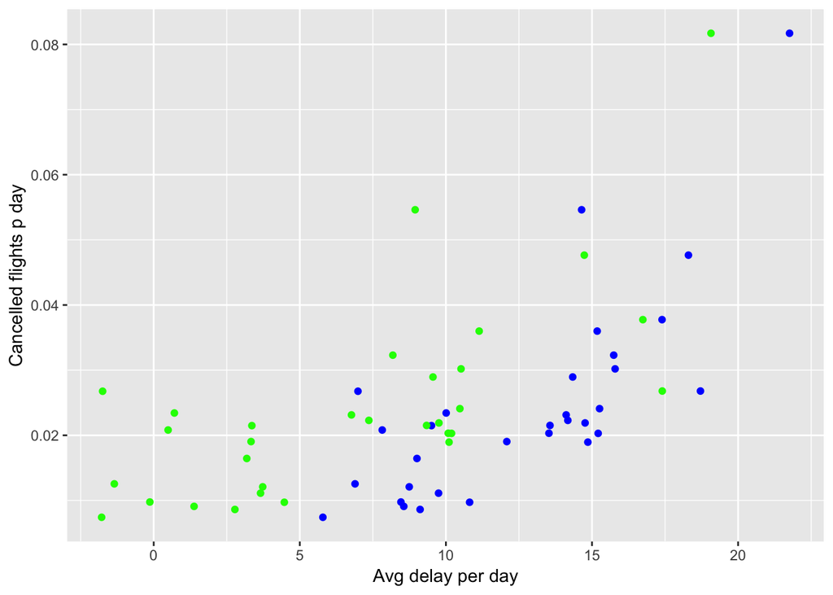

```r
flights %>%
  group_by(day) %>%
  summarise(cancelled = mean(is.na(dep_delay)),
            mean_dep = mean(dep_delay, na.rm = T),
            mean_arr = mean(arr_delay, na.rm = T)) %>%
  ggplot(aes(y = cancelled)) +
  geom_point(aes(x = mean_dep), colour = "blue") +
  geom_point(aes(x = mean_arr), colour = "green") +
  labs(x = "Avg delay per day", y = "Cancelled flights p day")
```

5. Which carrier has the worst delays? Challenge: can you disentangle the effects of bad airports vs. bad carriers? Why/why not? (Hint: think about flights %>% group_by(carrier, dest) %>% summarise(n()))

```r
flights %>%
  group_by(carrier) %>%
  summarise(dep_max = max(dep_delay, na.rm = T),
            arr_max = max(arr_delay, na.rm = T)) %>%
  arrange(desc(dep_max, arr_max)) %>%
  filter(1:n() == 1)
```

```
## # A tibble: 1 x 3
##   carrier dep_max arr_max
##   <chr>     <dbl>   <dbl>
## 1 HA         1301    1272
```

6. What does the sort argument to count() do. When might you use it?

Sort helps us to sort cases based on the count.

```r
flights %>%
  count(flight, sort = T)
```

```
## # A tibble: 3,844 x 2
##    flight     n
##     <int> <int>
##  1     15   968
##  2     27   898
##  3    181   882
##  4    301   871
##  5    161   786
##  6    695   782
##  7   1109   716
##  8    745   711
##  9    359   709
## 10      1   701
## # … with 3,834 more rows
```